# Week1OfficeHours

#### When looking for inclusive ranges

- P(*X* >= *a*) becomes P(*X* > *a* - 0.5)
- P(*X* <= *a*) becomes P(*X* < *a* + 0.5)

*But WHY?*

Think of it in two steps:

1. First, the equality bit or P(*X* = a)
2. Then, the greater or less than bit

Let’s do an example:

- P(*X* >= 1)
- First convert P(*X* = 1) ==> P(0.5 < *X* < 1.5)
- Drawing that looks like our prior example

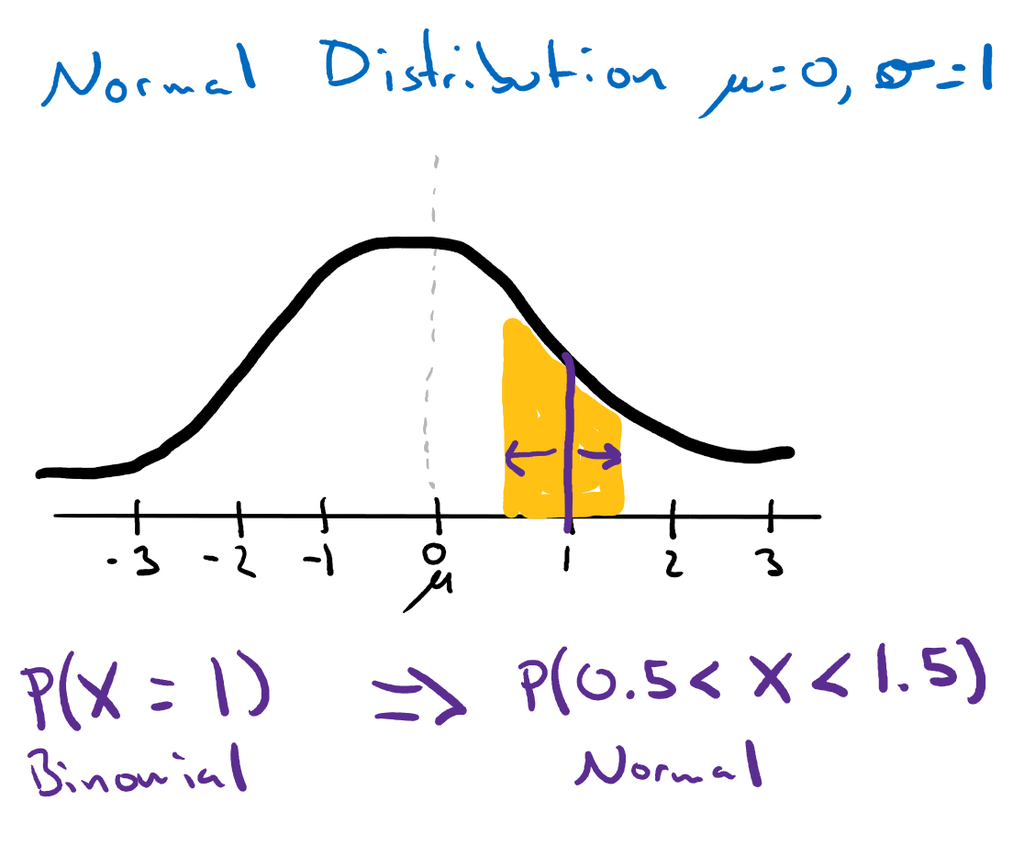

- Extend the shading to the right (for greater than) or to the left (for less than)
- Find the boundary of the shading, finding that we want P(*X* > 0.5)

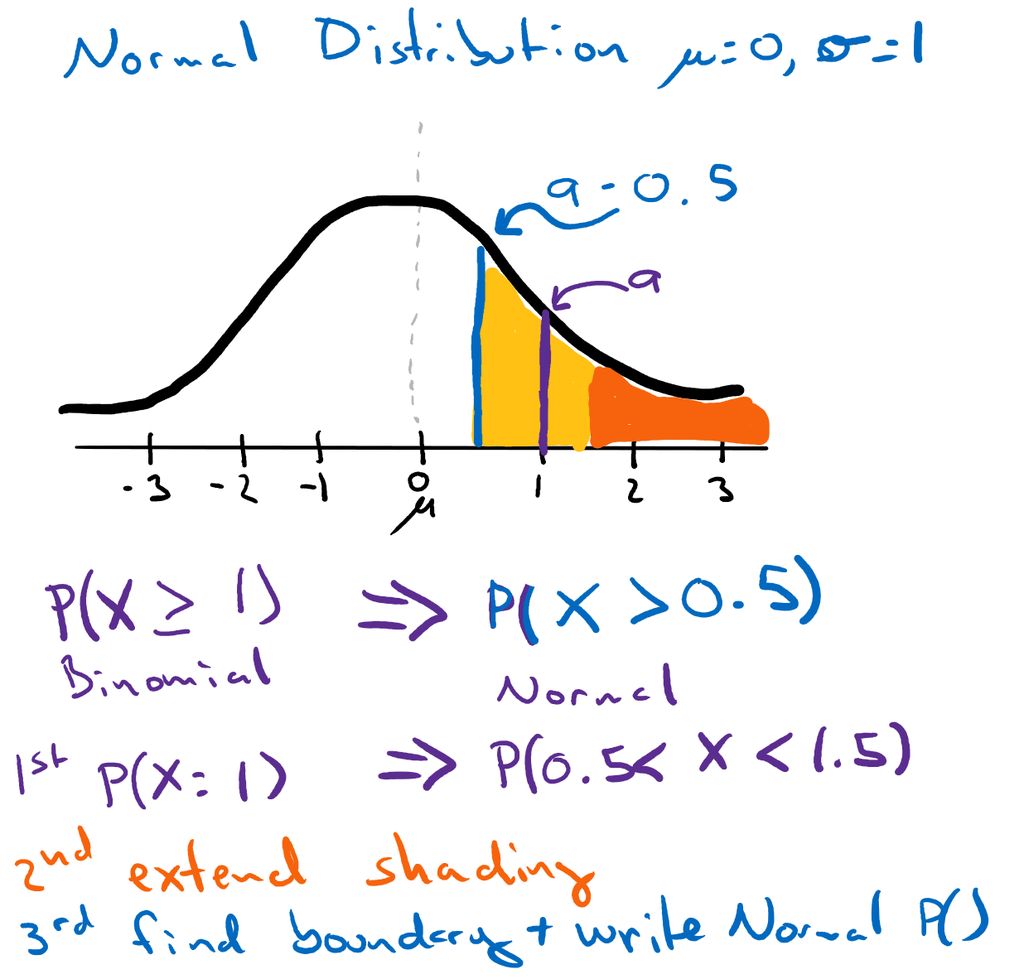

For the reverse P(*X* <= 1) it would look like this:

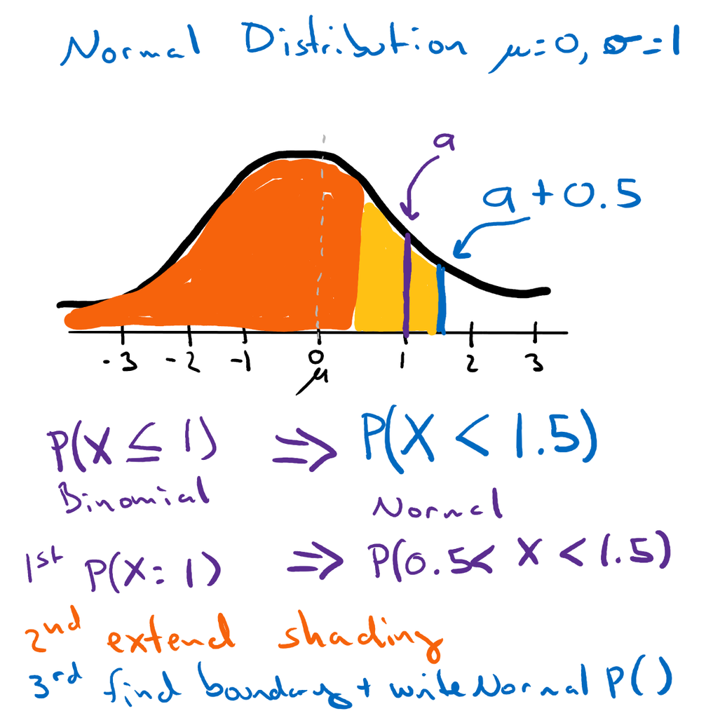

#### When looking for exclusive ranges

- P(*X* > *a*) becomes P(*X* > *a* + 0.5)
- P(*X* < *a*) becomes P(*X* < *a* - 0.5)

We swap adding or subtracting the 0.5 compared to the inclusive versions because we now want to exclude the “yellow” shading that represents the number itself.

Again here is an example for each.

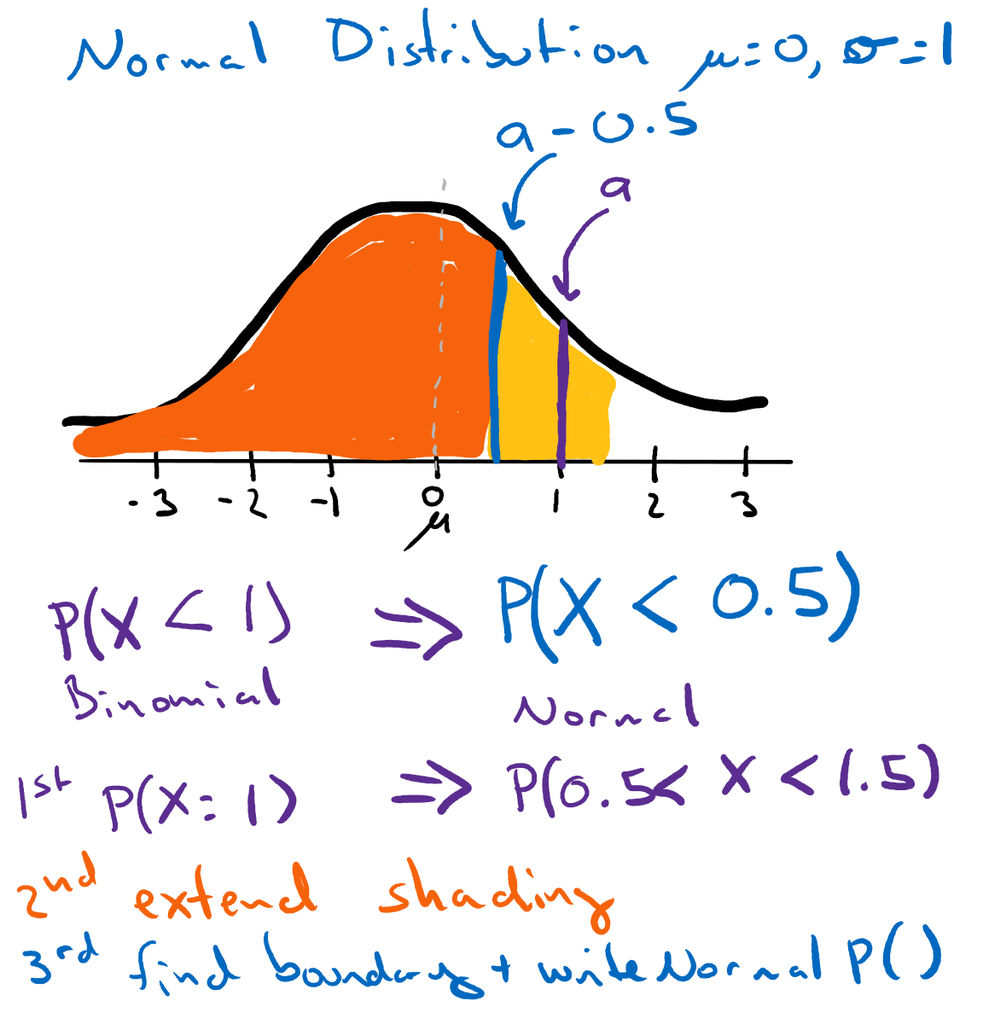

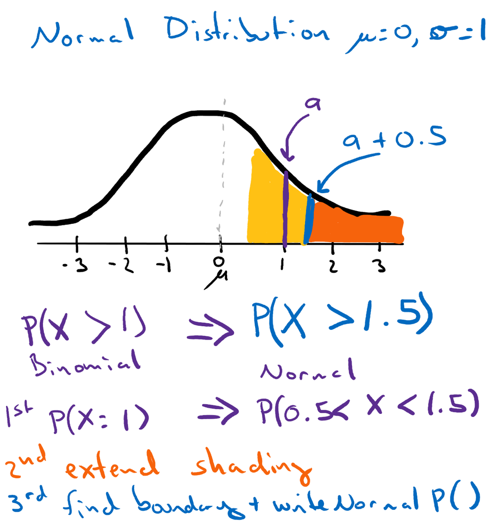

#### Wrapping up

Overall, rather than memorizing the formulas in Table 6-2, I hope you can now feel comfortable to apply the logic and drawings to make these conversions yourself. Remember, the core is about extending the area for a single integer +/- 0.5, then the rest is about deciding where to “draw the blue line” which becomes your value in the Normal approximation conversion.

### 2. What is a pipe `%>%`?

That symbol, referred to as a ‘pipe’ is a special function in the `dplyr` package. It tells R to take the output of the object on the left and ‘pipe’ it as input into the object on the right.

The goal of the pipe is to improve readability in code by avoiding nesting various `dplyr` or `tidyverse` functions. You can learn more about it and the best practices for how to use it in your code [here in the Tidyverse Style Guide](https://style.tidyverse.org/pipes.html). Here’s an example, using the Iris dataset, first though we’ll layout our Wants, Haves, and Process (a handy way to plan out a coding piece).

Want: for sepal length of each species, calculate the

- average
- median
- standard deviation

Have: iris dataset including

- Sepal.Length field provides lengths
- Species field provides species names

Process:

- Group data by species
- Summarize grouped data to calculate average, median, and standard deviation

```r
# without pipes
df_nopipes <- summarize(group_by(iris, Species),
                        Average = mean(Sepal.Length),
                        Median = median(Sepal.Length),
                        StandardDeviation = sd(Sepal.Length))
head(df_nopipes)
```

```
## # A tibble: 3 x 4
##   Species    Average Median StandardDeviation
##   <fct>        <dbl>  <dbl>             <dbl>
## 1 setosa        5.01    5               0.352
## 2 versicolor    5.94    5.9             0.516
## 3 virginica     6.59    6.5             0.636
```

```r
df_pipes <- iris %>%
  group_by(Species) %>%
  summarize(Average = mean(Sepal.Length),
            Median = median(Sepal.Length),
            StandardDeviation = sd(Sepal.Length))
head(df_pipes)
```

```
## # A tibble: 3 x 4
##   Species    Average Median StandardDeviation
##   <fct>        <dbl>  <dbl>             <dbl>
## 1 setosa        5.01    5               0.352
## 2 versicolor    5.94    5.9             0.516
## 3 virginica     6.59    6.5             0.636
```

As we learned in office hours today, `%>%` will provide the left-object’s output to the FIRST parameter in the right-object (or function). This means that you can use it with your own functions. I’ll show an example of these in the ggplot() wrapper below.

#### How much to pipe?

Generally, I like to keep my piping to a single core task (eg getting a summary table). If I then want to plot the data, I’ll do that as a separate set of commands (though technically you could pipe the data). This approach stems from the programming idea:

> A function should do ONE thing.

> Functions get large (and confusing) when they try to do more than one thing.

### 3. Example of using multiple rounds of grouping.

When working with event frequency data, where a row in the data represents a single data point, it is important to summarize to a base frequency before you can really dig into the stats. This is because each row is effectively a frequency of 1.

Here, I’ll share some code around:

1. Turning a timestamp string into a day-based date
2. Using summarize() and group_by() to get frequency per day (or daily rates)
3. Using summarize() and group_by() to get average daily rate for a year

#### Average daily rainfall for each year

Want:

- Total rainfall by day; averaged for each year

Have:

- Hourly rainfall (field HPCP) with a Timestamp string “YYYYMMDD HH:MM” (field = DATE)

Process:

- Split DATE string by white space " "
- Keep only first half containing the Date
- Store as “DAY” field
- Store first 4 characters of “DAY” as “YEAR” field
- *We are skipping converting these into date objects as that isn’t needed.*
- Group data by DAY and sum HPCP values –> store as dailyRain
- Group dailyRain by YEAR and average dailyRain values

```r
# based on example: https://rpubs.com/Mentors_Ubiqum/split_column
# strsplit(string, byvalue) returns a LIST of the split pieces
strsplit("Today is beautiful", " ")
```

```
## [[1]]
## [1] "Today"     "is"        "beautiful"
```

```r
# To ONLY get "Today" from this we can use the map() function to get a list with only the first element
strsplit("Today is beautiful", " ") %>%
  map(1)
```

```
## [[1]]
## [1] "Today"
```

```r
# Finally using as.character() will change the one-element list into a single value
strsplit("Today is beautiful", " ") %>%
  map(1) %>%
  as.character()
```

```
## [1] "Today"
```

```r
# wrapping these together, we can apply them to our data.frame field
rain$DAY <- as.character(map(strsplit(rain$DATE, " "), 1))

# get Substring of DAY for the YEAR
rain$YEAR <- substr(rain$DAY, 0, 4)
head(rain)
```

```
##       STATION           STATION_NAME           DATE HPCP      DAY YEAR
## 1 COOP:176905 PORTLAND JETPORT ME US 20000101 01:00 0.00 20000101 2000
## 2 COOP:176905 PORTLAND JETPORT ME US 20000102 12:00 0.00 20000102 2000
## 3 COOP:176905 PORTLAND JETPORT ME US 20000102 13:00 0.00 20000102 2000
## 4 COOP:176905 PORTLAND JETPORT ME US 20000102 14:00 0.02 20000102 2000
## 5 COOP:176905 PORTLAND JETPORT ME US 20000102 15:00 0.00 20000102 2000
## 6 COOP:176905 PORTLAND JETPORT ME US 20000102 18:00 0.01 20000102 2000
```

```r
dailyRain <- rain %>%
  group_by(DAY, YEAR) %>%  # bringing YEAR along for the ride
  summarize(dailyRain = sum(HPCP))
head(dailyRain)
```

```
## # A tibble: 6 x 3
## # Groups:   DAY [6]
##   DAY      YEAR  dailyRain
##   <chr>    <chr>     <dbl>
## 1 20000101 2000       0
## 2 20000102 2000       0.03
## 3 20000103 2000       0
## 4 20000104 2000       0.35
## 5 20000105 2000       0.21
## 6 20000107 2000       0.01
```

```r
yearlyAverage <- dailyRain %>%
  group_by(YEAR) %>%
  summarise(averageDaily = mean(dailyRain),
            std_devDaily = sd(dailyRain))
yearlyAverage
```

```
## # A tibble: 11 x 3
##    YEAR  averageDaily std_devDaily
##    <chr>        <dbl>        <dbl>
##  1 2000         0.213        0.356
##  2 2001         0.186        0.387
##  3 2002         0.205        0.329
##  4 2003         0.179        0.312
##  5 2004         0.216        0.402
##  6 2005         0.328        0.575
##  7 2006         0.317        0.536
##  8 2007         0.261        0.507
##  9 2008         0.313        0.559
## 10 2009         0.326        0.640
## 11 2010         0.310        0.636
```

```r
# alternatively, we could have piped this all together - though it certainly becomes trickier to "read"
yearlyAverage_alt <- rain %>%
  group_by(DAY) %>%
  summarize(dailyRain = sum(HPCP),
            YEAR = max(YEAR)) %>% # I'm bringing YEAR 'along for the ride' in a different way here
  group_by(YEAR) %>%
  summarise(averageDaily = mean(dailyRain),
            std_devDaily = sd(dailyRain))
yearlyAverage_alt
```

```
## # A tibble: 11 x 3
##    YEAR  averageDaily std_devDaily
##    <chr>        <dbl>        <dbl>
##  1 2000         0.213        0.356
##  2 2001         0.186        0.387
##  3 2002         0.205        0.329
##  4 2003         0.179        0.312
##  5 2004         0.216        0.402
##  6 2005         0.328        0.575
##  7 2006         0.317        0.536
##  8 2007         0.261        0.507
##  9 2008         0.313        0.559
## 10 2009         0.326        0.640
## 11 2010         0.310        0.636
```

### 4. Example of wrapping a ggplot() command in a function.

Here lets look at how we can create a custom function to make a type of plot over and over again. Generally my process is to:

1. Create a single ggplot() command to make the type of plot I want
2. Wrap it in a function() call
3. Customize function code to add flexibility through variables
4. Test run with same data used in step 1
5. Make LOTS of graphs!

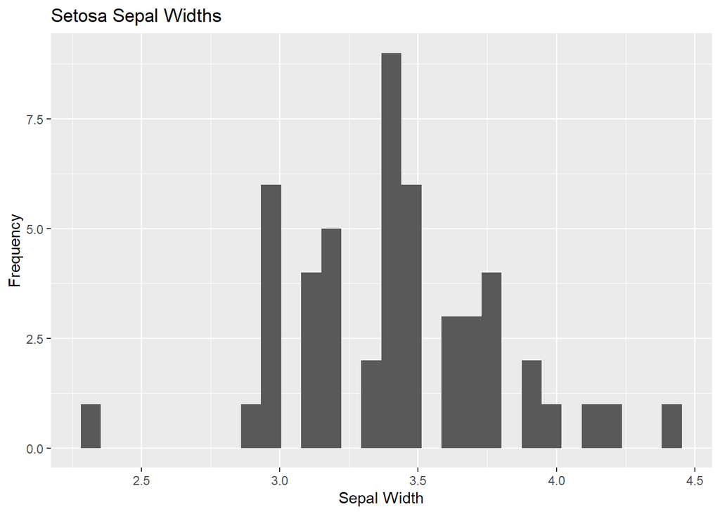

```r
# returning to the Iris data...
# 1. plot histogram of Sepal.Widths for a given species
(ggplot(iris[iris$Species == 'setosa',])
 + aes(x = Sepal.Width)
 + geom_histogram(bins = 30)
 + ggtitle("Setosa Sepal Widths")
 + scale_x_continuous("Sepal Width")
 + scale_y_continuous("Frequency")
 )
```

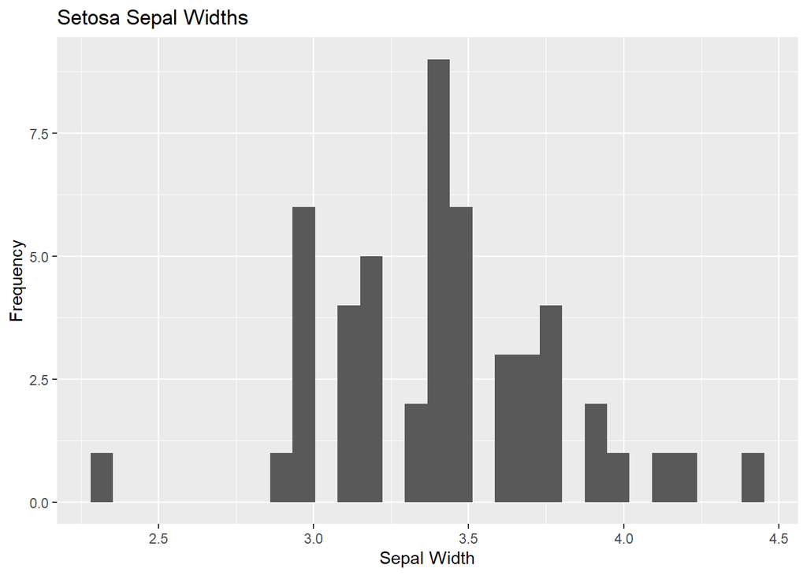

```r
# 2. wrap in a function; I like to start these with "plot" because that is what the function does
plotSepalWidth <- function(df, species) { # df is often used as a generic variable name for data.frame
  p <- (ggplot(df) # 3. replacing "iris[iris$Species == 'setosa',]" with "df"
   + aes(x = Sepal.Width)
   + geom_histogram(bins = 30)
   + ggtitle(paste(species, "Sepal Widths")) # 3. customize title
   + scale_x_continuous("Sepal Width")
   + scale_y_continuous("Frequency")
   )
  return(p)
}

# 4. test run with existing data
plotSepalWidth(iris[iris$Species == 'setosa',], species = 'Setosa')
```

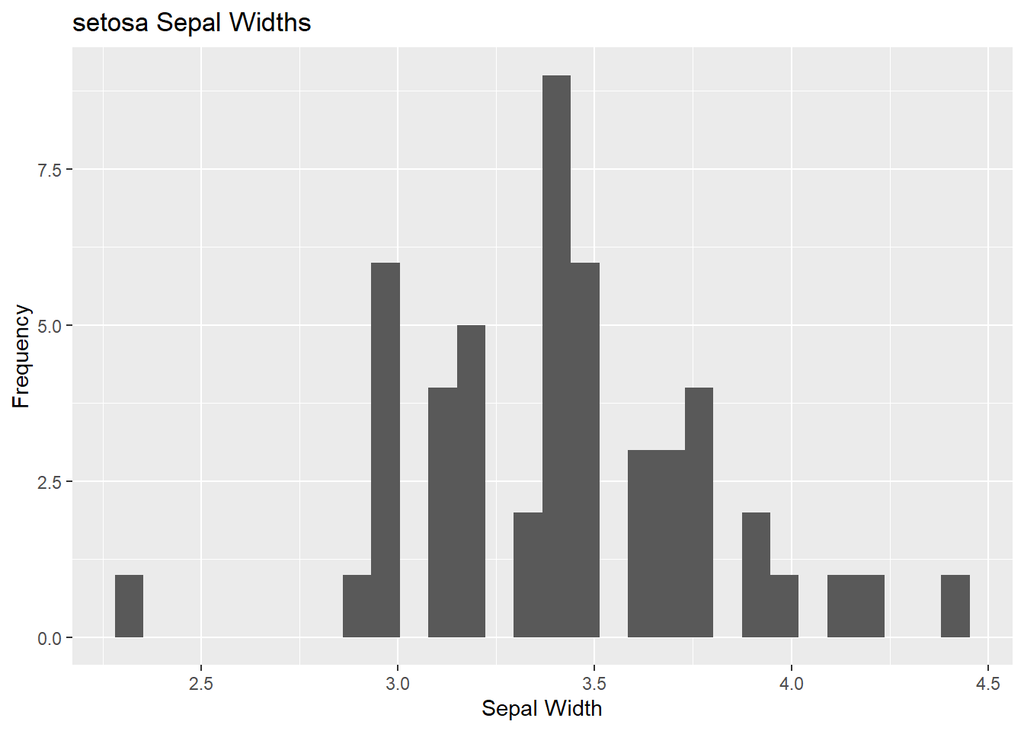

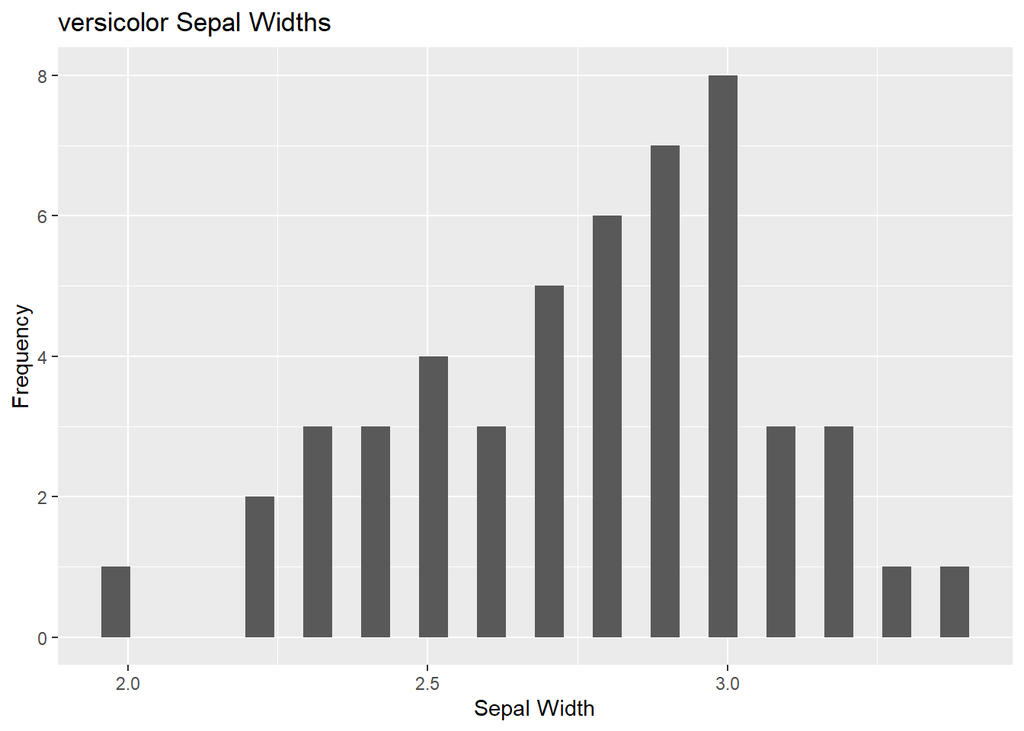

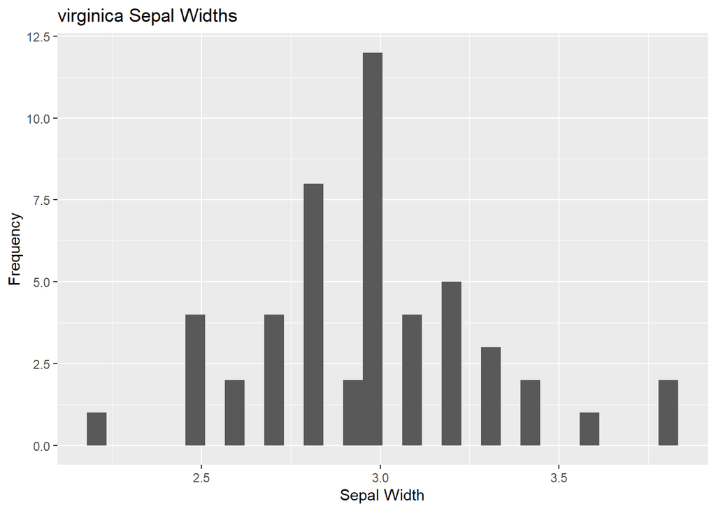

```r
# 5. use loops to RUN lots
for (species in unique(iris$Species)) {
  iris %>%
    filter(Species == species) %>%
    plotSepalWidth(species) %>%
    print() # call to explicitly print ggplot (required in loops)
}
```

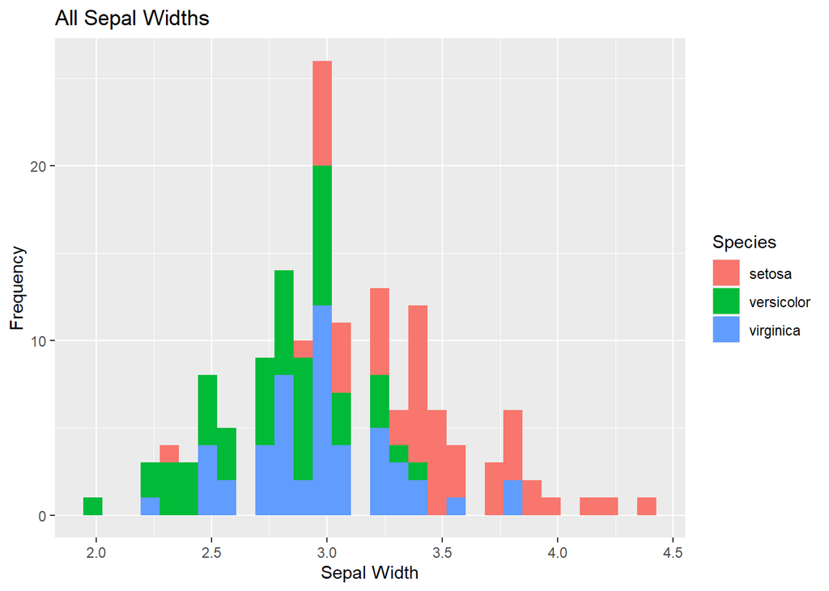

```r
# EXTRA: because our function returns the ggplot object AND those are designed to be built upon, we can add more specifics to our plot after running the function.

# here I'm plotting all the data and coloring it by species
plotSepalWidth(iris, "All") + aes(fill = Species)
```